# Bhaswar Chakma

## About

Hi! I am Bhaswar Chakma. Born and raised in [Chittagong Hill Tracts, Bangladesh](https://en.wikipedia.org/wiki/Chittagong_Hill_Tracts), I have been living in Portugal since 2014. I became a Portuguese citizen in April 2021. Outside of work, I love to play the guitar. Here are some of my favorite songs: [Cliffs Of Dover](https://www.youtube.com/watch?v=aiRn3Zlw3Rw); [Always with Me, Always with you](https://www.youtube.com/watch?v=vxeYDEOXsqU); [Electric Gypsy](https://www.youtube.com/watch?v=JIl3V9SdNKY). Let me know if you need more suggestions!

Fun Fact: My last name – [Chakma](https://en.wikipedia.org/wiki/Chakma_people) – happens to be the name of the indigenous community that I belong to.

You can reach me at bhaswar.chakma@outlook.com.

*Last updated: 2021-07-17*

## CV

Click [here](https://www.dropbox.com/s/d58j65cxk4d9u22/CV-Bhaswar-Chakma.pdf?dl=0).

## Personal Projects

- [toolbox](https://bhaswar-chakma.github.io/toolbox/): I am writing this “book” for future-me! This is kind of quick reference guide. It contains `Python`, `R`, and `SQL` topics. I am adding materials almost every day. Hope to add `Julia` someday!
- [dse](https://bhaswar-chakma.github.io/dse/): This site is about Dhaka Stock Exchange, includes market stats and visualizations. I try to update this site almost every working day!
- [brmlab2021](https://brmlab2021.netlify.app): I built this site for teaching, used this in Spring 2020/21 at CLSBE.

## My Countries

#### GDP

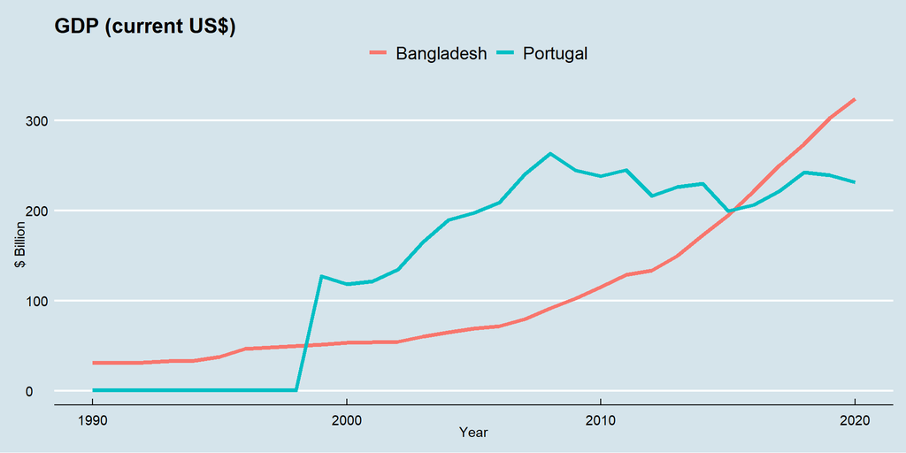

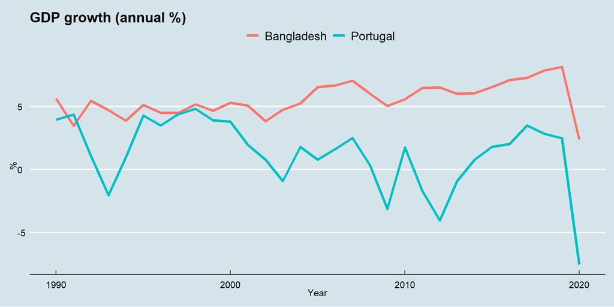

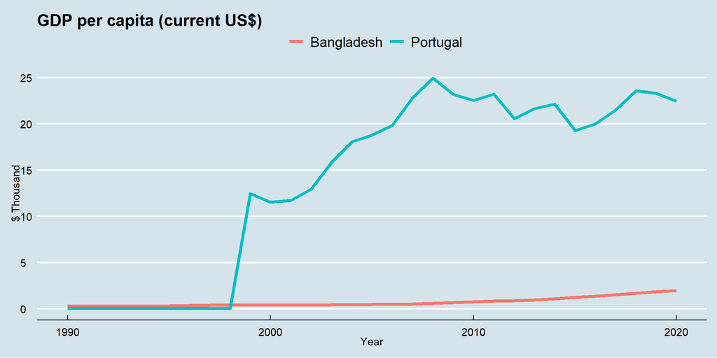

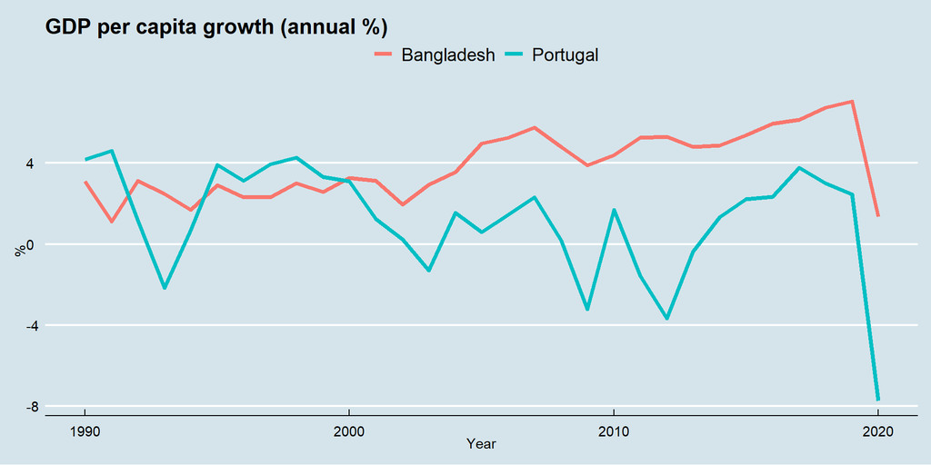

#### Population & Life Expectency

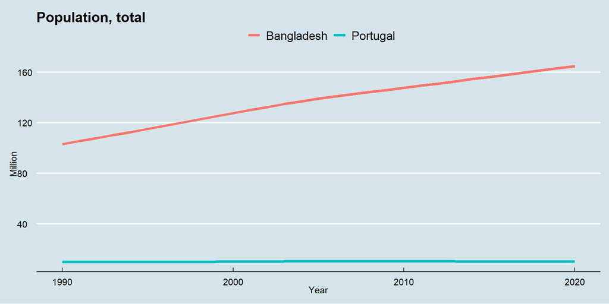

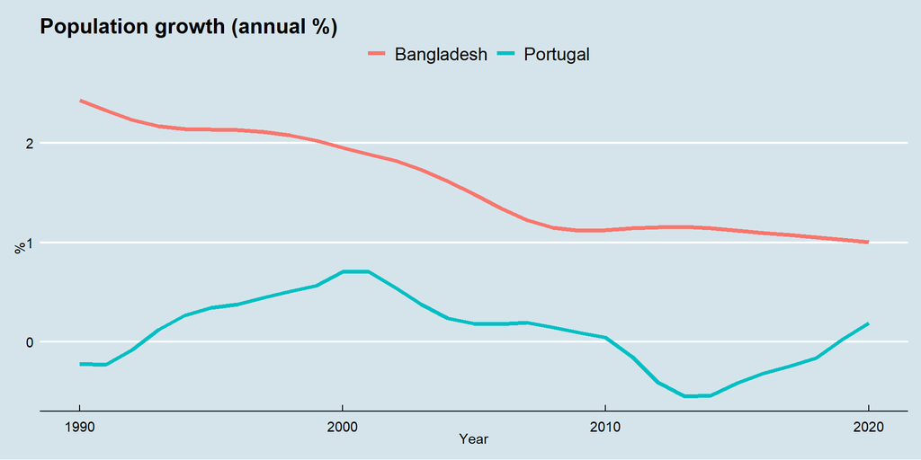

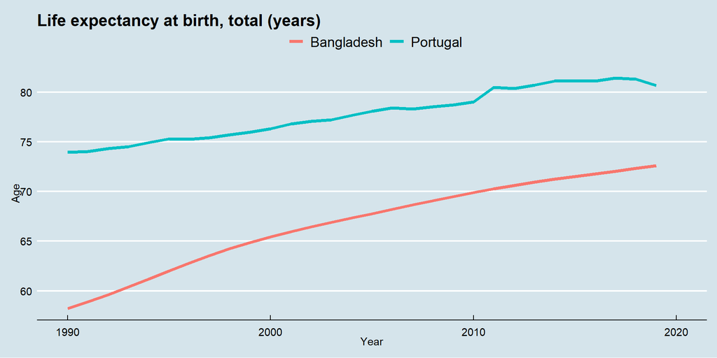

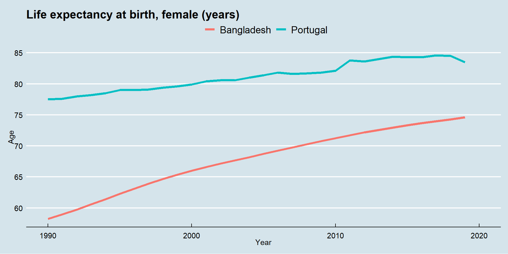

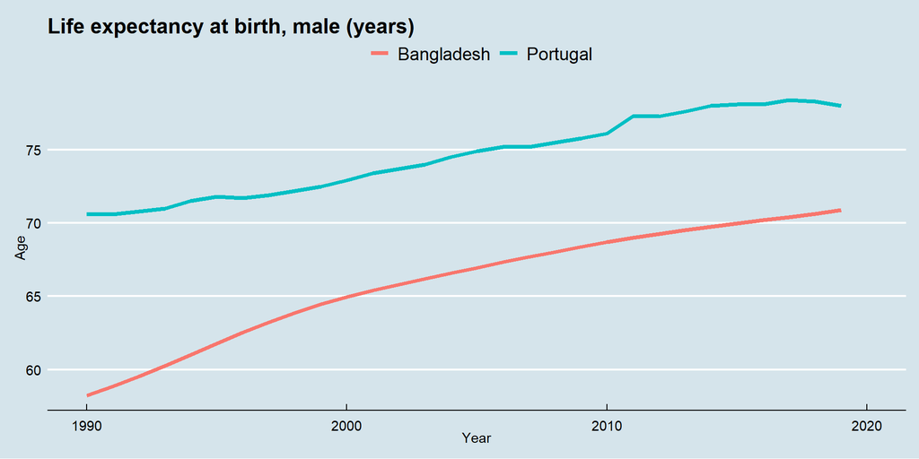

#### Trade

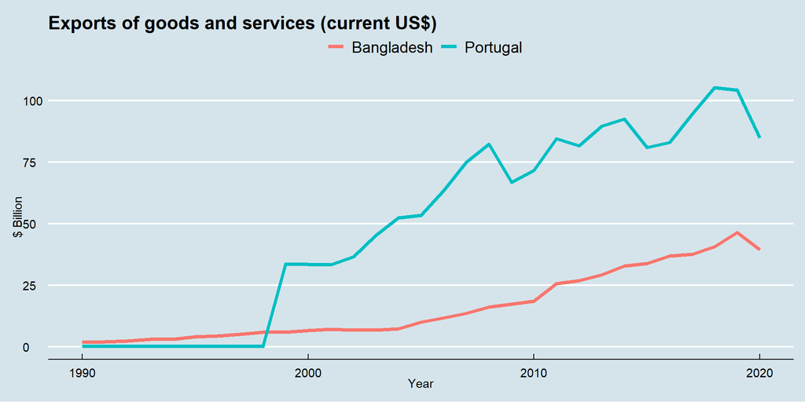

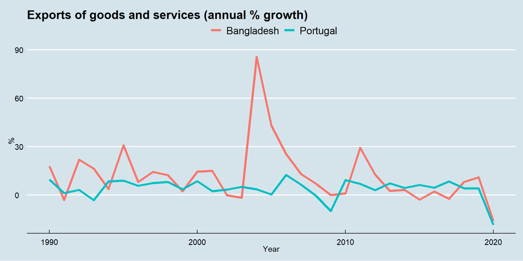

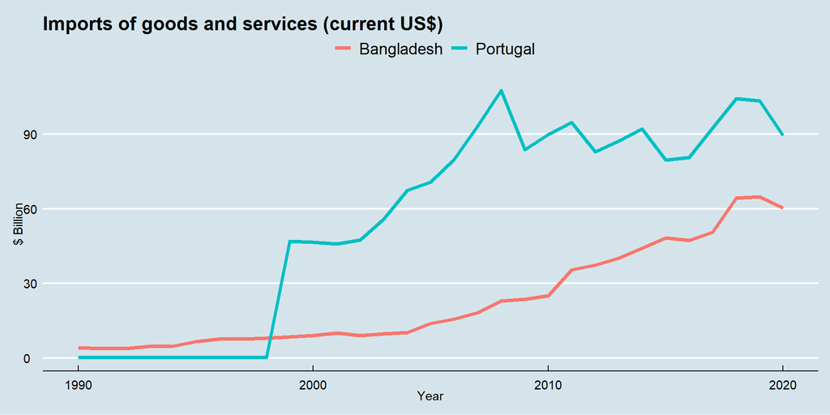

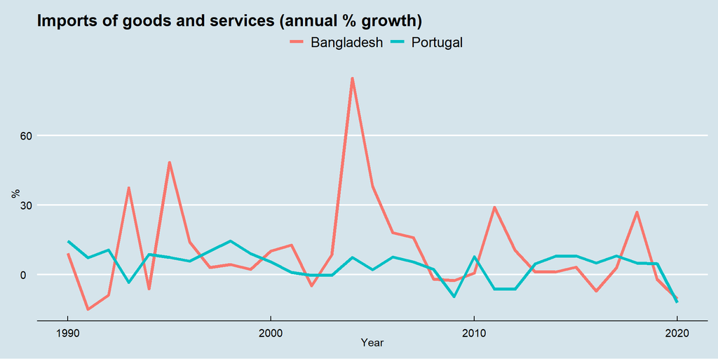

#### FDI & Remittance

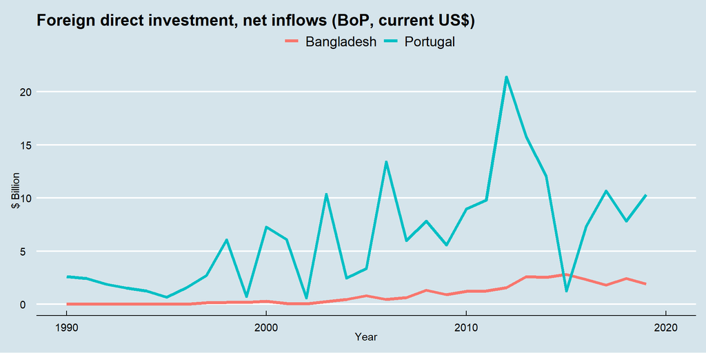

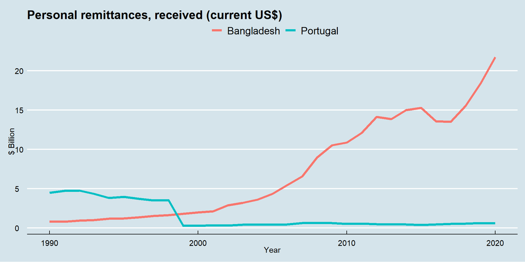